# Annotation Report

Resistance genes and determinants annotated using NCBI-AMRFinderPlus and CARD-RGI tools

Ecoli genome assembly

28 março 2020

# About

Resistance genes or resistance determinants confer to the bacteria the ability to tolerate or resist some antibiotics or antimicrobials. Which means, these characteristics makes the bacteria less susceptible to its effects.

Resistance determinants were predicted using [AMRFinderPlus](https://github.com/ncbi/amr/wiki). This is a binary distributed by NCBI that allows users to query the National Database of Antibiotic Resistant Organisms ([NDARO](https://www.ncbi.nlm.nih.gov/pathogens/antimicrobial-resistance/)). This is a NCBI curated database that aggregates resistance genes from other databases such as [Resfams](http://www.dantaslab.org/resfams), [CARD](https://card.mcmaster.ca/), ResFinder, Pasteur Institute Beta Lactamases and orthers. For more information please read the following [link](https://www.ncbi.nlm.nih.gov/bioproject/PRJNA313047). NCBI’s efforts were done in order to standardise and confer reliability to AMR predictions.

Additionally, resistance determinants were also detected with [CARD RGI](https://github.com/arpcard/rgi) tool which enables the detection of new variants and mutations that confer resistance to antibiotics. The RGI analyzes genome or proteome sequences under three paradigms: **Perfect**, **Strict**, and **Loose** (a.k.a. Discovery). **The Perfect algorithm** is most often applied to clinical surveillance as it detects perfect matches to the curated reference sequences and mutations in the CARD. In contrast, **the Strict algorithm** detects previously unknown variants of known AMR genes, including secondary screen for key mutations, using detection models with CARD’s curated similarity cut-offs to ensure the detected variant is likely a functional AMR gene.

# Results

## AMRFinder

Below it is summarized the result obtained with AMRFinderPlus. Roughly, it can be divided into two main categories:

1. Genes related to antibiotics, called AMR;
2. Genes related to stress resistance which can be:
   - biocide resistance
   - metal resistance
   - heat resistance

- **AMR genes found in the query genome:**
  - oqxB
  - oqxA
  - blaSHV-11
  - emrD
  - fosA
  - kdeA
  - blaKPC-2
  - sul1
  - tet(A)
  - qnrS1
  - blaLAP-2
  - sul2
  - tet(D)

### Supporting Data

| Resistance Type | Query Protein ID | Gene Name | Product | Target Drug Class | Annotation Method | Reference Sequence | Genome Coordinates |
| --- | --- | --- | --- | --- | --- | --- | --- |
| AMR | AENPOJHA_00531 | oqxB | multidrug efflux RND transporter permease subunit OqxB | PHENICOL/QUINOLONE | EXACTP | WP_000347934.1 | AENPOJHA_00531 : 226133 - 229285 |
| AMR | AENPOJHA_00532 | oqxA | multidrug efflux RND transporter periplasmic adaptor subunit OqxA | PHENICOL/QUINOLONE | EXACTP | WP_002914189.1 | AENPOJHA_00532 : 229309 - 230484 |
| AMR | AENPOJHA_02017 | blaSHV-11 | class A broad-spectrum beta-lactamase SHV-11 | BETA-LACTAM | ALLELEP | WP_004176269.1 | AENPOJHA_02017 : 122078 - 122938 |
| AMR | AENPOJHA_03444 | emrD | multidrug efflux MFS transporter EmrD | EFFLUX | BLASTP | ACN65732.1 | AENPOJHA_03444 : 79634 - 80818 |
| AMR | AENPOJHA_04241 | fosA | FosA family fosfomycin resistance glutathione transferase | FOSFOMYCIN | BLASTP | WP_004146118.1 | AENPOJHA_04241 : 6312 - 6731 |
| AMR | AENPOJHA_04364 | kdeA | multidrug efflux MFS transporter KdeA | EFFLUX | BLASTP | ABR76310.1 | AENPOJHA_04364 : 3921 - 5153 |
| AMR | AENPOJHA_04813 | blaKPC-2 | carbapenem-hydrolyzing class A beta-lactamase KPC-2 | BETA-LACTAM | ALLELEP | WP_004199234.1 | AENPOJHA_04813 : 11112 - 11993 |
| AMR | AENPOJHA_04879 | sul1 | sulfonamide-resistant dihydropteroate synthase Sul1 | SULFONAMIDE | EXACTP | WP_000259031.1 | AENPOJHA_04879 : 2725 - 3564 |
| AMR | AENPOJHA_04883 | tet(A) | tetracycline efflux MFS transporter Tet(A) | TETRACYCLINE | EXACTP | WP_000804064.1 | AENPOJHA_04883 : 6315 - 7514 |
| AMR | AENPOJHA_05172 | qnrS1 | quinolone resistance pentapeptide repeat protein QnrS1 | QUINOLONE | ALLELEP | WP_001516695.1 | AENPOJHA_05172 : 749 - 1405 |

[output cut: 9 more lines]

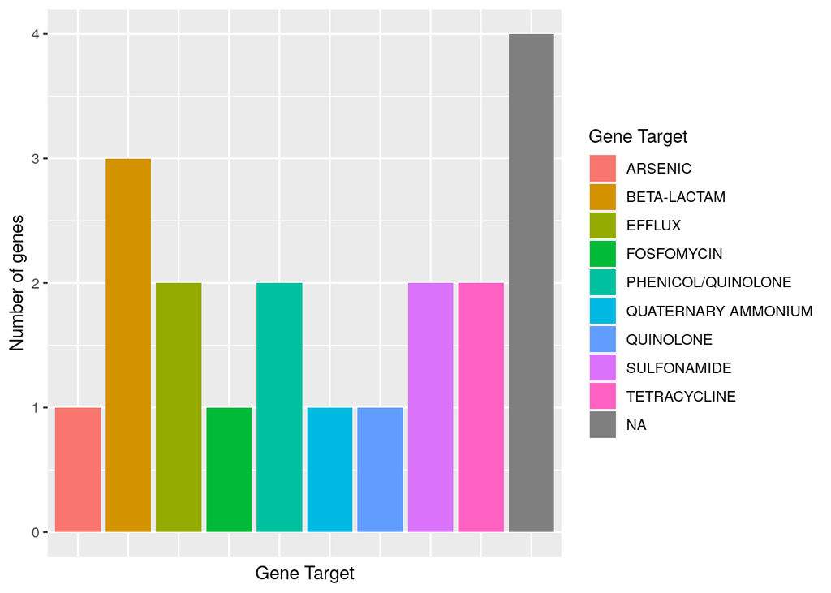

Figure 1: Resistome Predicted using NCBI’s AMRFinderplus

## CARD RGI

Below it is summarized the result obtained with RGI. Roughly, it can be divided into two main categories:

1. Perfect hits
   - detects perfect matches to the curated reference sequences and mutations in the CARD
   - Perfect hits are genes that CARD guarantee its functionality. Which means that these genes are likely functional and might be confering resistance to the bacteria.
2. Strict hits
   - detects previously unknown variants of known AMR genes, including secondary screen for key mutations, using detection models with CARD’s curated similarity cut-offs to ensure the detected variant is likely a functional AMR gene

**Obs:** CARD RGI tool always tries to annotate functional AMR genes, however, depending on the assembly, a not functional gene may yet be annotated. There for, users are advised to double check genes annotated under Strict category.

### Results

#### Perfect Hits

Perfect hits are genes that CARD guarantee its functionality. Which means that these genes are likely functional and might be confering resistance to the bacteria.

- **Drug Classes targeted by the query genome:**
  - aminoglycoside antibiotic
  - carbapenem
  - cephalosporin
  - diaminopyrimidine antibiotic
  - fluoroquinolone antibiotic
  - glycylcycline
  - macrolide antibiotic
  - monobactam
  - nitrofuran antibiotic
  - penam
  - peptide antibiotic
  - rifamycin antibiotic
  - sulfonamide antibiotic
  - tetracycline antibiotic

| Gene | Resistance Mechanism | Drug Class | ARO | CARD Link | Genome Coordinates | Description |
| --- | --- | --- | --- | --- | --- | --- |
| Klebsiella pneumoniae KpnF | antibiotic efflux | macrolide antibiotic; aminoglycoside antibiotic; cephalosporin; tetracycline antibiotic; peptide antibiotic; rifamycin antibiotic | 3004583 | 42513 | AENPOJHA_01974 : 81735 - 82064 | KpnF subunit of KpnEF resembles EbrAB from E. coli. Mutation in KpnEF resulted in increased susceptibility to cefepime, ceftriaxon, colistin, erythromycin, rifampin, tetracycline, and streptomycin as … |
| KPC-2 | antibiotic inactivation | monobactam; carbapenem; cephalosporin; penam | 3002312 | 38712 | AENPOJHA_04813 : 11112 - 11993 | KPC-2 is a beta-lactamase found in Klebsiella pneumoniae and Pseudomonas aeruginosa. |
| LAP-2 | antibiotic inactivation | fluoroquinolone antibiotic; aminoglycoside antibiotic; tetracycline antibiotic; rifamycin antibiotic | 3004826 | 42956 | AENPOJHA_05176 : 3002 - 3859 | LAP-2 is an Ambler Class A beta-lactamase gene conferring resistance to quinolones. |
| oqxA | antibiotic efflux | fluoroquinolone antibiotic; glycylcycline; tetracycline antibiotic; diaminopyrimidine antibiotic; nitrofuran antibiotic | 3003922 | 40631 | AENPOJHA_00532 : 229309 - 230484 | RND efflux pump conferring resistance to fluoroquinolone |
| oqxB | antibiotic efflux | fluoroquinolone antibiotic; glycylcycline; tetracycline antibiotic; diaminopyrimidine antibiotic; nitrofuran antibiotic | 3003923 | 40632 | AENPOJHA_00531 : 226133 - 229285 | RND efflux pump conferring resistance to fluoroquinolone |
| QnrS1 | antibiotic target protection | fluoroquinolone antibiotic | 3002790 | 39224 | AENPOJHA_05172 : 749 - 1405 | QnrS1 is a plasmid-mediated quinolone resistance protein found in Shigella flexneri |
| SHV-11 | antibiotic inactivation | carbapenem; cephalosporin; penam | 3001070 | 37450 | AENPOJHA_02017 : 122078 - 122938 | SHV-11 is a broad-spectrum beta-lactamase found in E. coli, Klebsiella pneumoniae, Proteus mirabilis, and Shigella dysenteriae. |
| sul1 | antibiotic target replacement | sulfonamide antibiotic | 3000410 | 36549 | AENPOJHA_04879 : 2725 - 3564 | Sul1 is a sulfonamide resistant dihydropteroate synthase of Gram-negative bacteria. It is linked to other resistance genes of class 1 integrons. |
| sul2 | antibiotic target replacement | sulfonamide antibiotic | 3000412 | 36551 | AENPOJHA_05339 : 3807 - 4622 | Sul2 is a sulfonamide resistant dihydropteroate synthase of Gram-negative bacteria, usually found on small plasmids. |
| tet(D) | antibiotic efflux | tetracycline antibiotic | 3000168 | 36307 | AENPOJHA_05419 : 1642 - 2826 | TetD is a tetracycline efflux pump found exclusively in Gram-negative bacteria. |

[figure not shown]

#### Strict Hits

Strict hits genes are genes annotated with looser parameters and are not surely functional or correct. Which means, users should double check genes under this category.

- **Drug Classes targeted by the query genome:**
  - aminocoumarin antibiotic
  - aminoglycoside antibiotic
  - carbapenem
  - cephalosporin
  - cephamycin
  - fluoroquinolone antibiotic
  - fosfomycin
  - glycylcycline
  - macrolide antibiotic
  - monobactam
  - nitroimidazole antibiotic
  - penam
  - penem
  - peptide antibiotic
  - phenicol antibiotic
  - rifamycin antibiotic
  - tetracycline antibiotic
  - triclosan

| Gene | Resistance Mechanism | Drug Class | ARO | CARD Link | Genome Coordinates | Description |
| --- | --- | --- | --- | --- | --- | --- |
| adeF | antibiotic efflux | fluoroquinolone antibiotic; tetracycline antibiotic | 3000777 | 37157 | AENPOJHA_02425 : 40504 - 43617 | AdeF is the membrane fusion protein of the multidrug efflux complex AdeFGH. |
| baeR | antibiotic efflux | aminoglycoside antibiotic; aminocoumarin antibiotic | 3000828 | 37208 | AENPOJHA_04521 : 25520 - 26242 | BaeR is a response regulator that promotes the expression of MdtABC and AcrD efflux complexes. |
| CRP | antibiotic efflux | macrolide antibiotic; fluoroquinolone antibiotic; penam | 3000518 | 36657 | AENPOJHA_01510 : 187862 - 188494 | CRP is a global regulator that represses MdtEF multidrug efflux pump expression. |
| emrR | antibiotic efflux | fluoroquinolone antibiotic | 3000516 | 36655 | AENPOJHA_00486 : 181333 - 181863 | EmrR is a negative regulator for the EmrAB-TolC multidrug efflux pump in E. coli. Mutations lead to EmrAB-TolC overexpression. |
| Escherichia coli ampH beta-lactamase | antibiotic inactivation | cephalosporin; penam | 3004612 | 42576 | AENPOJHA_01868 : 157636 - 158796 | AmpH is a class C ampC-like beta-lactamase and penicillin-binding protein identified in Escherichia coli. |
| Escherichia coli gyrA conferring resistance to fluoroquinolones | antibiotic target alteration | fluoroquinolone antibiotic | 3003294 | 39878 | AENPOJHA_02290 : 45873 - 48506 | Point mutation of Escherichia coli gyrA resulted in the lowered affinity between fluoroquinolones and gyrA. Thus, conferring resistance |
| Escherichia coli marR mutant conferring antibiotic resistance | antibiotic target alteration; antibiotic efflux | fluoroquinolone antibiotic; cephalosporin; glycylcycline; penam; tetracycline antibiotic; rifamycin antibiotic; phenicol antibiotic; triclosan | 3003378 | 39962 | AENPOJHA_02038 : 143436 - 143870 | MarR is a repressor of the mar operon marRAB, thus regulating the expression of marA, the activator of multidrug efflux pump AcrAB. |
| Escherichia coli parC conferring resistance to fluoroquinolone | antibiotic target alteration | fluoroquinolone antibiotic | 3003308 | 39892 | AENPOJHA_00633 : 29749 - 32007 | Point mutation in Escherichia coli parC resulting in fluoroquinolone resistance |
| Escherichia coli UhpT with mutation conferring resistance to fosfomycin | antibiotic target alteration | fosfomycin | 3003890 | 40592 | AENPOJHA_03454 : 89092 - 90483 | Mutations to the active importer UhpT, which is involved with the uptake of many phosphorylated sugars, confer resistance to fosfomycin by reducing import of the drug into the bacteria. |
| FosA6 | antibiotic inactivation | fosfomycin | 3004111 | 41232 | AENPOJHA_04241 : 6312 - 6731 | fosA6 is a plasmid-encoded enzyme that confers resistance to fosfomycin in Escherichia coli by breaking the epoxide ring of the molecule. |

[output cut: 10 more lines]

[figure not shown]

## Prokka

Table 1: Prokka Generic Resistance Feature

[output not shown]

[output cut: 5431 more lines]